# CASA0005 第一周：地理信息、数据连接与输出

按[官方第 1 章](https://andrewmaclachlan.github.io/CASA0005repo/geographic-information.html)顺序整理地理信息、读取、连接与输出。打开课程 `casa0005.Rproj`，代码按顺序运行；Knit 从头计算普通分析块；安装、导出与可选联网分支单独执行。

来源：MacLachlan、Dennett、Dooley；[CC BY-SA 4.0](https://creativecommons.org/licenses/by-sa/4.0/)。中文整理与适配经 AI 辅助，见改编范围；源版本 `0b19a3339034e3bd3de1e8246559d453301f07eb`。

## 1.4 数据与 Excel 透视表

原始数据来自 London Data Store，存于 `data/raw/london/`。Shapefile 的 shp、shx、dbf、prj 配套保留。Excel 透视表以地区代码为行、年份为列、`total_action_taken` 为值并求和，去掉额外标题和总计，另存 `week01/data/processed/fly-tipping-pivot.csv`。

## 1.5 包与项目

安装块仅在缺包时运行。

```r
install.packages(c("sf", "tidyverse", "tmap", "RSQLite"))
```

## 加载工具

`sf` 处理矢量，`tidyverse` 整理表格，`tmap` 制图，`RSQLite` 读写数据库。

```r
helper <- c("tutorial-tools.R", "../tutorial-tools.R")
source(helper[file.exists(helper)][1])
gis_packages(c("sf", "tidyverse", "tmap", "RSQLite"))
library(sf)
library(tidyverse)
library(tmap)
root <- gis_root()
```

## 读取边界

`shape` 包含行政区属性和 geometry；`st_crs()` 查看坐标参考系，`st_geometry()` 只取形状。

```r
boundary <- gis_file("data/raw/london/boundaries/statistical-gis-boundaries-london/ESRI/London_Borough_Excluding_MHW.shp",
                     "^London_Borough_Excluding_MHW\\.shp$")
shape <- sf::st_read(boundary, quiet = TRUE)
gis_unique(shape, "GSS_CODE")
summary(shape)
```

```
##         NAME         GSS_CODE     HECTARES         NONLD_AREA
##  Length   :33   Length   :33   Min.   :  314.9   Min.   :  0.00
##  N.unique :33   N.unique :33   1st Qu.: 2724.9   1st Qu.:  0.00
##  N.blank  : 0   N.blank  : 0   Median : 3857.8   Median :  2.30
##  Min.nchar: 5   Min.nchar: 9   Mean   : 4832.4   Mean   : 64.22
##  Max.nchar:22   Max.nchar: 9   3rd Qu.: 5658.5   3rd Qu.: 95.60
##                                Max.   :15013.5   Max.   :370.62
##      ONS_INNER       SUB_2009       SUB_2006           geometry
##  Length   :33   Length   :33   Length   :33   MULTIPOLYGON :33
##  N.unique : 2   N.unique : 0   N.unique : 0   epsg:NA      : 0
##  N.blank  : 0   N.blank  : 0   N.blank  : 0   +proj=tmer...: 0
##  Min.nchar: 1   Min.nchar:NA   Min.nchar:NA
##  Max.nchar: 1   Max.nchar:NA   Max.nchar:NA
##                 NAs      :33   NAs      :33
```

```r
sf::st_crs(shape)
```

```
## Coordinate Reference System:
##   User input: OSGB36 / British National Grid
##   wkt:
## PROJCRS["OSGB36 / British National Grid",
##     BASEGEOGCRS["OSGB36",
##         DATUM["Ordnance Survey of Great Britain 1936",
##             ELLIPSOID["Airy 1830",6377563.396,299.3249646,
##                 LENGTHUNIT["metre",1]],
##             ID["EPSG",6277]],
##         PRIMEM["Greenwich",0,
##             ANGLEUNIT["Degree",0.0174532925199433]]],
##     CONVERSION["unnamed",
##         METHOD["Transverse Mercator",
##             ID["EPSG",9807]],
##         PARAMETER["Latitude of natural origin",49,
##             ANGLEUNIT["Degree",0.0174532925199433],
##             ID["EPSG",8801]],
##         PARAMETER["Longitude of natural origin",-2,
##             ANGLEUNIT["Degree",0.0174532925199433],
##             ID["EPSG",8802]],
##         PARAMETER["Scale factor at natural origin",0.999601272,
##             SCALEUNIT["unity",1],
##             ID["EPSG",8805]],
##         PARAMETER["False easting",400000,
##             LENGTHUNIT["metre",1],
##             ID["EPSG",8806]],
##         PARAMETER["False northing",-100000,
##             LENGTHUNIT["metre",1],
##             ID["EPSG",8807]]],
##     CS[Cartesian,2],
##         AXIS["(E)",east,
##             ORDER[1],
##             LENGTHUNIT["metre",1,
##                 ID["EPSG",9001]]],
##         AXIS["(N)",north,
##             ORDER[2],
##             LENGTHUNIT["metre",1,
##                 ID["EPSG",9001]]]]
```

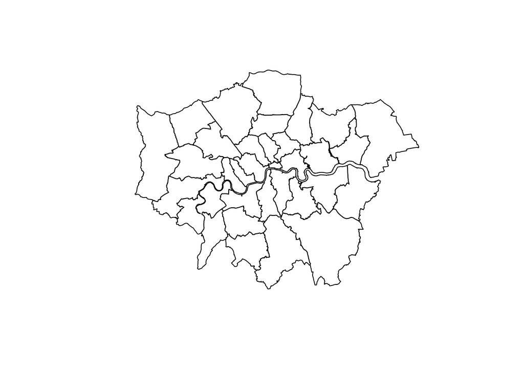

```r
plot(sf::st_geometry(shape))
```

## 读取属性表

优先读取本周透视表；否则使用保留的 GB18030 中文宽表，规范代码、年份和总计字段。

```r
pivot_file <- file.path(root, "week01/data/processed/fly-tipping-pivot.csv")
if (file.exists(pivot_file)) {
  mycsv <- readr::read_csv(pivot_file, show_col_types = FALSE)
} else {

  mycsv <- readr::read_csv(
    gis_file("data/raw/london/attributes/fly-tipping-borough.csv"),
    locale = readr::locale(encoding = "GB18030"), show_col_types = FALSE)
}
names(mycsv)
```

```
##  [1] "行标签"    "2012-13"   "2013-14"   "2014-15"   "2015-16"   "2016-17"
##  [7] "2017-18"   "2018-19"   "2019-20"   "2020-21"   "2021-22"   "2022-23"
## [13] "2023-24"   "2024-25"   "2011/12/1" "总计"
```

```r
if ("Row Labels" %in% names(mycsv)) mycsv <- dplyr::rename(mycsv, GSS_CODE = `Row Labels`)
if ("行标签" %in% names(mycsv)) mycsv <- dplyr::rename(mycsv, GSS_CODE = `行标签`)
if ("2011/12/1" %in% names(mycsv)) mycsv <- dplyr::rename(mycsv, `2011_12` = `2011/12/1`)
gis_columns(mycsv, "GSS_CODE")
mycsv <- mycsv %>%
  dplyr::filter(GSS_CODE != "总计") %>%
  dplyr::select(-dplyr::any_of("总计")) %>%
  dplyr::rename_with(~ gsub("-", "_", .x))
gis_unique(mycsv, "GSS_CODE")
```

## 按代码连接

两侧 `anti_join()` 检查未匹配，唯一键验证后执行一对一左连接。

```r
if (!exists("shape", inherits = FALSE)) {
  stop("当前会话没有 shape：请先运行 read-boundary，再运行本块。", call. = FALSE)
}
if (!exists("mycsv", inherits = FALSE)) {
  stop("当前会话没有 mycsv：请先运行 read-pivot，再运行本块。", call. = FALSE)
}
gis_unique(shape, "GSS_CODE")
gis_unique(mycsv, "GSS_CODE")
dplyr::anti_join(sf::st_drop_geometry(shape), mycsv, by = "GSS_CODE")
```

```
## [1] NAME       GSS_CODE   HECTARES   NONLD_AREA ONS_INNER  SUB_2009   SUB_2006
## <0 rows> (or 0-length row.names)
```

```r
dplyr::anti_join(mycsv, sf::st_drop_geometry(shape), by = "GSS_CODE")
```

```
## # A tibble: 0 × 15
## # ℹ 15 variables: GSS_CODE <chr>, 2012_13 <dbl>, 2013_14 <dbl>, 2014_15 <dbl>,
## #   2015_16 <dbl>, 2016_17 <dbl>, 2017_18 <dbl>, 2018_19 <dbl>, 2019_20 <dbl>,
## #   2020_21 <dbl>, 2021_22 <dbl>, 2022_23 <dbl>, 2023_24 <dbl>, 2024_25 <dbl>,
## #   2011_12 <dbl>
```

```r
shape2 <- dplyr::left_join(shape, mycsv, by = "GSS_CODE", relationship = "one-to-one")
stopifnot(nrow(shape2) == nrow(shape))
head(sf::st_drop_geometry(shape2), 10)
```

```
##                    NAME  GSS_CODE  HECTARES NONLD_AREA ONS_INNER SUB_2009
## 1  Kingston upon Thames E09000021  3726.117      0.000         F     <NA>
## 2               Croydon E09000008  8649.441      0.000         F     <NA>
## 3               Bromley E09000006 15013.487      0.000         F     <NA>
## 4              Hounslow E09000018  5658.541     60.755         F     <NA>
## 5                Ealing E09000009  5554.428      0.000         F     <NA>
## 6              Havering E09000016 11445.735    210.763         F     <NA>
## 7            Hillingdon E09000017 11570.063      0.000         F     <NA>
## 8                Harrow E09000015  5046.330      0.000         F     <NA>
## 9                 Brent E09000005  4323.270      0.000         F     <NA>
## 10               Barnet E09000003  8674.837      0.000         F     <NA>
##    SUB_2006 2012_13 2013_14 2014_15 2015_16 2016_17 2017_18 2018_19 2019_20
## 1      <NA>       0       0       0       0       0       3      21     482
## 2      <NA>     108     460     712    1775     637    2684    1994    2660
## 3      <NA>     479     653     462     326     228     258     287     211
```

[output cut: 18 more lines]

## 专题地图

`2011_12` 表示 2011–12 年采取行动次数，不是事件总数；缺失值保留为 NA。

```r
year_column <- "2011_12"
gis_columns(shape2, year_column)
tmap::tmap_mode("plot")
```

```
## ℹ tmap modes "plot" - "view"
## ℹ toggle with `tmap::ttm()`
```

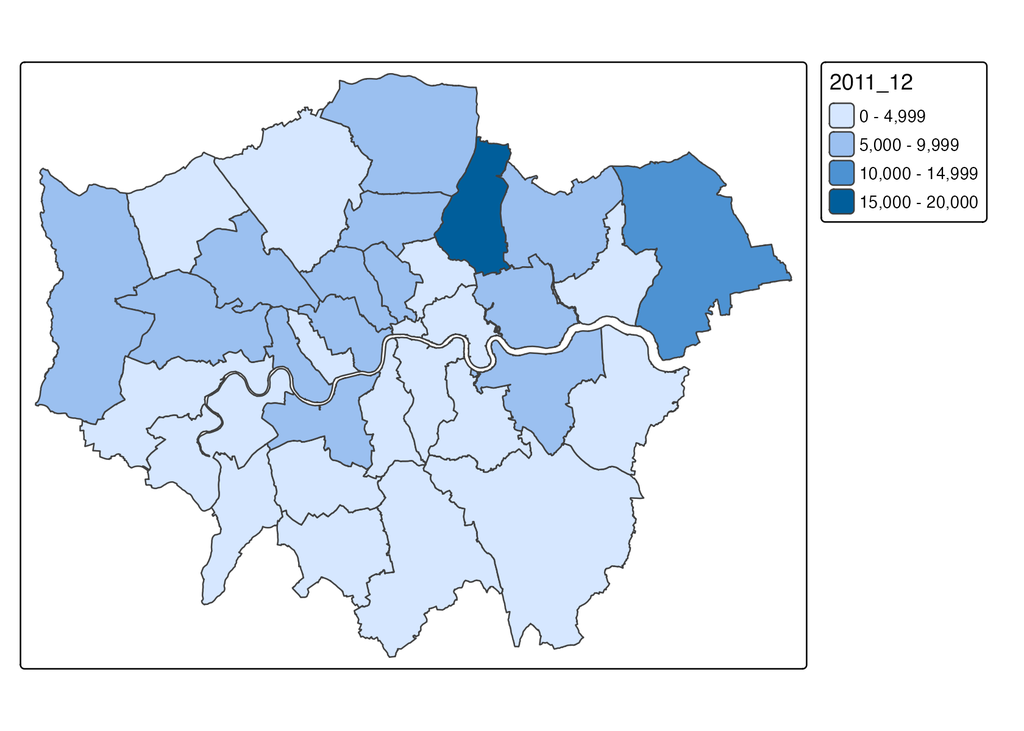

```r
tmap::tm_shape(shape2) + tmap::tm_polygons(fill = year_column)
```

## 导出 GeoPackage

导出连接后的 `shape2`，另加 `original_csv` 表；时间戳文件名保留旧结果。

```r
target <- gis_new_output("week01", paste0("flytipping-tutorial-",
  format(Sys.time(), "%Y%m%d-%H%M%S"), ".gpkg"))
sf::st_write(shape2, target, layer = "london_boroughs_fly_tipping", quiet = TRUE)
con <- DBI::dbConnect(RSQLite::SQLite(), dbname = target)
tryCatch({
  print(DBI::dbListTables(con))
  DBI::dbWriteTable(con, "original_csv", as.data.frame(mycsv), overwrite = FALSE)
}, finally = DBI::dbDisconnect(con))
sf::st_layers(target)
```

## Homework：新西兰

使用 Territorial Authority 2018 generalised 边界和 Census 的 `2018 paid employee`。此块仅检查工作表，完整处理见 homework.Rmd。SA1 与 territorial authority 是不同空间层级。

```r
library(readxl)
census <- gis_file("data/raw/nz2018/census/2018-SA1-dataset-individual-part-3a-total-NZ_updated_16-7-20.xlsx")
readxl::excel_sheets(census)
preview <- readxl::read_excel(census, sheet = "Territorial authority", col_names = FALSE, n_max = 12)
preview
```

## 资料链接

- [官方第1章](https://andrewmaclachlan.github.io/CASA0005repo/geographic-information.html)
- [London Data Store](https://data.london.gov.uk/)